# Ensemble Techniques_R4_Project1_Parkinson’s Disease

```python
# basic packages
import pandas as pd
import numpy as np

# for charts and plot
import matplotlib.pyplot as plt
import seaborn as sns

# for test train split
from sklearn.model_selection import train_test_split

# for accuracy score
from sklearn.metrics import accuracy_score

# Label Encoding the non numerical columns
from sklearn.preprocessing import LabelEncoder

# Building the model using Decision Tree
from sklearn.tree import DecisionTreeClassifier

# ensemble using Random Forest Classifier
from sklearn.ensemble import RandomForestClassifier, AdaBoostClassifier, GradientBoostingClassifier
```

### Loading Data

```python
df = pd.read_csv('./parkinsons.data')
```

```python
df.head()
```

|  | name | MDVP:Fo(Hz) | MDVP:Fhi(Hz) | MDVP:Flo(Hz) | MDVP:Jitter(%) | MDVP:Jitter(Abs) | MDVP:RAP | MDVP:PPQ | Jitter:DDP | MDVP:Shimmer | ... | Shimmer:DDA | NHR | HNR | status | RPDE | DFA | spread1 | spread2 | D2 | PPE |
| --- | --- | --- | --- | --- | --- | --- | --- | --- | --- | --- | --- | --- | --- | --- | --- | --- | --- | --- | --- | --- | --- |
| 0 | phon_R01_S01_1 | 119.992 | 157.302 | 74.997 | 0.00784 | 0.00007 | 0.00370 | 0.00554 | 0.01109 | 0.04374 | ... | 0.06545 | 0.02211 | 21.033 | 1 | 0.414783 | 0.815285 | -4.813031 | 0.266482 | 2.301442 | 0.284654 |
| 1 | phon_R01_S01_2 | 122.400 | 148.650 | 113.819 | 0.00968 | 0.00008 | 0.00465 | 0.00696 | 0.01394 | 0.06134 | ... | 0.09403 | 0.01929 | 19.085 | 1 | 0.458359 | 0.819521 | -4.075192 | 0.335590 | 2.486855 | 0.368674 |
| 2 | phon_R01_S01_3 | 116.682 | 131.111 | 111.555 | 0.01050 | 0.00009 | 0.00544 | 0.00781 | 0.01633 | 0.05233 | ... | 0.08270 | 0.01309 | 20.651 | 1 | 0.429895 | 0.825288 | -4.443179 | 0.311173 | 2.342259 | 0.332634 |
| 3 | phon_R01_S01_4 | 116.676 | 137.871 | 111.366 | 0.00997 | 0.00009 | 0.00502 | 0.00698 | 0.01505 | 0.05492 | ... | 0.08771 | 0.01353 | 20.644 | 1 | 0.434969 | 0.819235 | -4.117501 | 0.334147 | 2.405554 | 0.368975 |
| 4 | phon_R01_S01_5 | 116.014 | 141.781 | 110.655 | 0.01284 | 0.00011 | 0.00655 | 0.00908 | 0.01966 | 0.06425 | ... | 0.10470 | 0.01767 | 19.649 | 1 | 0.417356 | 0.823484 | -3.747787 | 0.234513 | 2.332180 | 0.410335 |

5 rows × 24 columns

```python
df.info()
```

```
<class 'pandas.core.frame.DataFrame'>
RangeIndex: 195 entries, 0 to 194
Data columns (total 24 columns):
name                195 non-null object
MDVP:Fo(Hz)         195 non-null float64
MDVP:Fhi(Hz)        195 non-null float64
MDVP:Flo(Hz)        195 non-null float64
MDVP:Jitter(%)      195 non-null float64
MDVP:Jitter(Abs)    195 non-null float64
MDVP:RAP            195 non-null float64
MDVP:PPQ            195 non-null float64
Jitter:DDP          195 non-null float64
MDVP:Shimmer        195 non-null float64
MDVP:Shimmer(dB)    195 non-null float64
Shimmer:APQ3        195 non-null float64
Shimmer:APQ5        195 non-null float64
MDVP:APQ            195 non-null float64
Shimmer:DDA         195 non-null float64
NHR                 195 non-null float64
HNR                 195 non-null float64
status              195 non-null int64
RPDE                195 non-null float64
DFA                 195 non-null float64
spread1             195 non-null float64
spread2             195 non-null float64
D2                  195 non-null float64
PPE                 195 non-null float64
dtypes: float64(22), int64(1), object(1)
memory usage: 36.6+ KB
```

```python
for col in df.columns:
    print('NaN in columns {} is {}'.format(col, df[df[col].isna()][col].sum()))
```

```
NaN in columns name is 0
NaN in columns MDVP:Fo(Hz) is 0.0
NaN in columns MDVP:Fhi(Hz) is 0.0
NaN in columns MDVP:Flo(Hz) is 0.0
NaN in columns MDVP:Jitter(%) is 0.0
NaN in columns MDVP:Jitter(Abs) is 0.0
NaN in columns MDVP:RAP is 0.0
NaN in columns MDVP:PPQ is 0.0
NaN in columns Jitter:DDP is 0.0
NaN in columns MDVP:Shimmer is 0.0
NaN in columns MDVP:Shimmer(dB) is 0.0
NaN in columns Shimmer:APQ3 is 0.0
NaN in columns Shimmer:APQ5 is 0.0
NaN in columns MDVP:APQ is 0.0
NaN in columns Shimmer:DDA is 0.0
NaN in columns NHR is 0.0
NaN in columns HNR is 0.0
NaN in columns status is 0
NaN in columns RPDE is 0.0
NaN in columns DFA is 0.0
NaN in columns spread1 is 0.0
NaN in columns spread2 is 0.0
NaN in columns D2 is 0.0
NaN in columns PPE is 0.0
```

- There are no NaN values in the columns of the given dataset.

```python
df.describe().T
```

|  | count | mean | std | min | 25% | 50% | 75% | max |
| --- | --- | --- | --- | --- | --- | --- | --- | --- |
| MDVP:Fo(Hz) | 195.0 | 154.228641 | 41.390065 | 88.333000 | 117.572000 | 148.790000 | 182.769000 | 260.105000 |
| MDVP:Fhi(Hz) | 195.0 | 197.104918 | 91.491548 | 102.145000 | 134.862500 | 175.829000 | 224.205500 | 592.030000 |
| MDVP:Flo(Hz) | 195.0 | 116.324631 | 43.521413 | 65.476000 | 84.291000 | 104.315000 | 140.018500 | 239.170000 |
| MDVP:Jitter(%) | 195.0 | 0.006220 | 0.004848 | 0.001680 | 0.003460 | 0.004940 | 0.007365 | 0.033160 |
| MDVP:Jitter(Abs) | 195.0 | 0.000044 | 0.000035 | 0.000007 | 0.000020 | 0.000030 | 0.000060 | 0.000260 |
| MDVP:RAP | 195.0 | 0.003306 | 0.002968 | 0.000680 | 0.001660 | 0.002500 | 0.003835 | 0.021440 |
| MDVP:PPQ | 195.0 | 0.003446 | 0.002759 | 0.000920 | 0.001860 | 0.002690 | 0.003955 | 0.019580 |
| Jitter:DDP | 195.0 | 0.009920 | 0.008903 | 0.002040 | 0.004985 | 0.007490 | 0.011505 | 0.064330 |
| MDVP:Shimmer | 195.0 | 0.029709 | 0.018857 | 0.009540 | 0.016505 | 0.022970 | 0.037885 | 0.119080 |
| MDVP:Shimmer(dB) | 195.0 | 0.282251 | 0.194877 | 0.085000 | 0.148500 | 0.221000 | 0.350000 | 1.302000 |
| Shimmer:APQ3 | 195.0 | 0.015664 | 0.010153 | 0.004550 | 0.008245 | 0.012790 | 0.020265 | 0.056470 |
| Shimmer:APQ5 | 195.0 | 0.017878 | 0.012024 | 0.005700 | 0.009580 | 0.013470 | 0.022380 | 0.079400 |
| MDVP:APQ | 195.0 | 0.024081 | 0.016947 | 0.007190 | 0.013080 | 0.018260 | 0.029400 | 0.137780 |
| Shimmer:DDA | 195.0 | 0.046993 | 0.030459 | 0.013640 | 0.024735 | 0.038360 | 0.060795 | 0.169420 |
| NHR | 195.0 | 0.024847 | 0.040418 | 0.000650 | 0.005925 | 0.011660 | 0.025640 | 0.314820 |
| HNR | 195.0 | 21.885974 | 4.425764 | 8.441000 | 19.198000 | 22.085000 | 25.075500 | 33.047000 |
| status | 195.0 | 0.753846 | 0.431878 | 0.000000 | 1.000000 | 1.000000 | 1.000000 | 1.000000 |
| RPDE | 195.0 | 0.498536 | 0.103942 | 0.256570 | 0.421306 | 0.495954 | 0.587562 | 0.685151 |
| DFA | 195.0 | 0.718099 | 0.055336 | 0.574282 | 0.674758 | 0.722254 | 0.761881 | 0.825288 |
| spread1 | 195.0 | -5.684397 | 1.090208 | -7.964984 | -6.450096 | -5.720868 | -5.046192 | -2.434031 |
| spread2 | 195.0 | 0.226510 | 0.083406 | 0.006274 | 0.174351 | 0.218885 | 0.279234 | 0.450493 |
| D2 | 195.0 | 2.381826 | 0.382799 | 1.423287 | 2.099125 | 2.361532 | 2.636456 | 3.671155 |
| PPE | 195.0 | 0.206552 | 0.090119 | 0.044539 | 0.137451 | 0.194052 | 0.252980 | 0.527367 |

```python
df.columns
```

```
Index(['name', 'MDVP:Fo(Hz)', 'MDVP:Fhi(Hz)', 'MDVP:Flo(Hz)', 'MDVP:Jitter(%)',
       'MDVP:Jitter(Abs)', 'MDVP:RAP', 'MDVP:PPQ', 'Jitter:DDP',
       'MDVP:Shimmer', 'MDVP:Shimmer(dB)', 'Shimmer:APQ3', 'Shimmer:APQ5',
       'MDVP:APQ', 'Shimmer:DDA', 'NHR', 'HNR', 'status', 'RPDE', 'DFA',
       'spread1', 'spread2', 'D2', 'PPE'],
      dtype='object')
```

### Cleaning of Data:

- Cleaning of data is not required becauses the distribution reveals that they values is not wrong or incorrect inputs.
- There is only marginal difference in the data points that are deemed as outliers, hence there is not much cleaning of data required.

### Data Representation

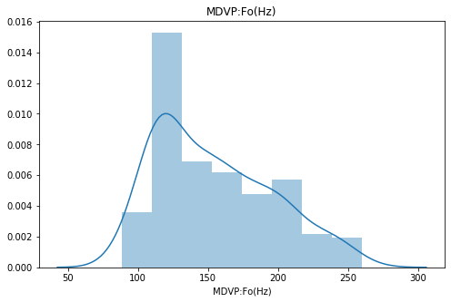

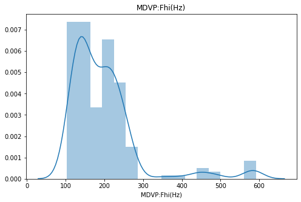

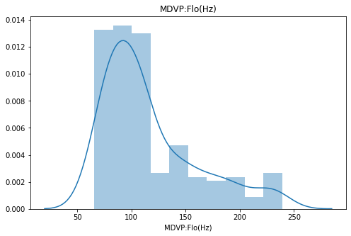

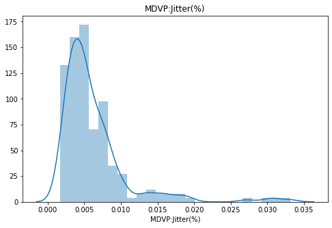

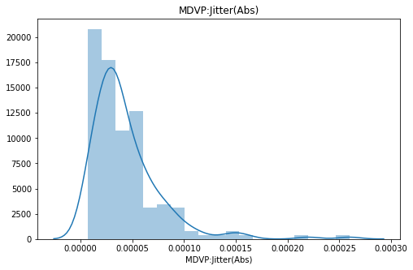

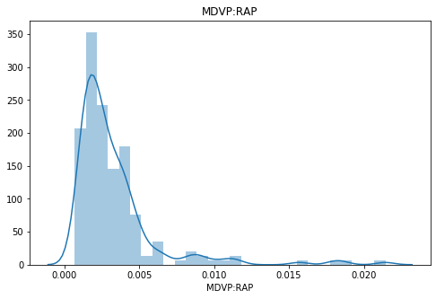

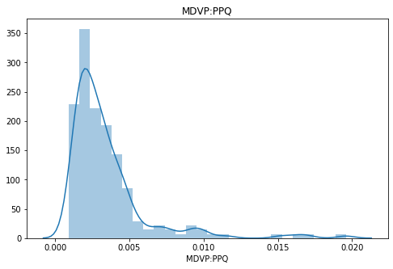

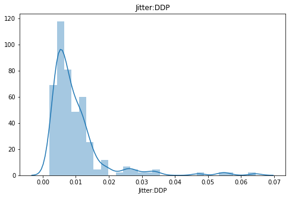

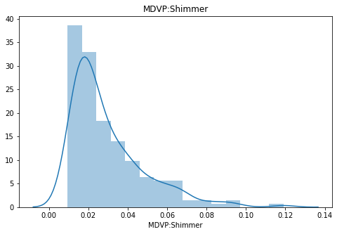

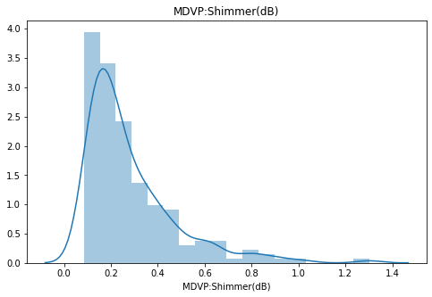

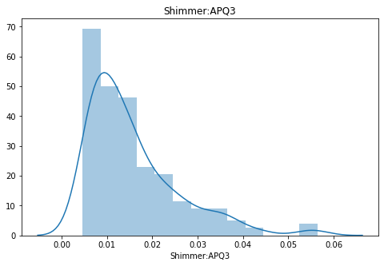

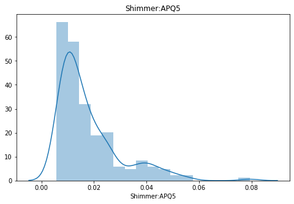

[11 more figures not shown]

```python
cols = ['MDVP:Fo(Hz)', 'MDVP:Fhi(Hz)', 'MDVP:Flo(Hz)', 'MDVP:Jitter(%)',
       'MDVP:Jitter(Abs)', 'MDVP:RAP', 'MDVP:PPQ', 'Jitter:DDP',
       'MDVP:Shimmer', 'MDVP:Shimmer(dB)', 'Shimmer:APQ3', 'Shimmer:APQ5',
       'MDVP:APQ', 'Shimmer:DDA', 'NHR', 'HNR', 'status', 'RPDE', 'DFA',
       'spread1', 'spread2', 'D2', 'PPE']
for col in cols:
    plt.figure(figsize=(8,5))
    plt.title(col)
    sns.distplot(df[col]);
    plt.show()
```

- Upon plotting the distribution plot we can see that certain columns are right skewed revealing that there might be outliars.
- There are also columns that are evenly distributed.
- Columns that are evenly disributed.
  - D2
  - Spread2
  - Spread1
  - DFA
  - HNR
- Rest of the columns are right skewed.

#### Correlation Heat Map:

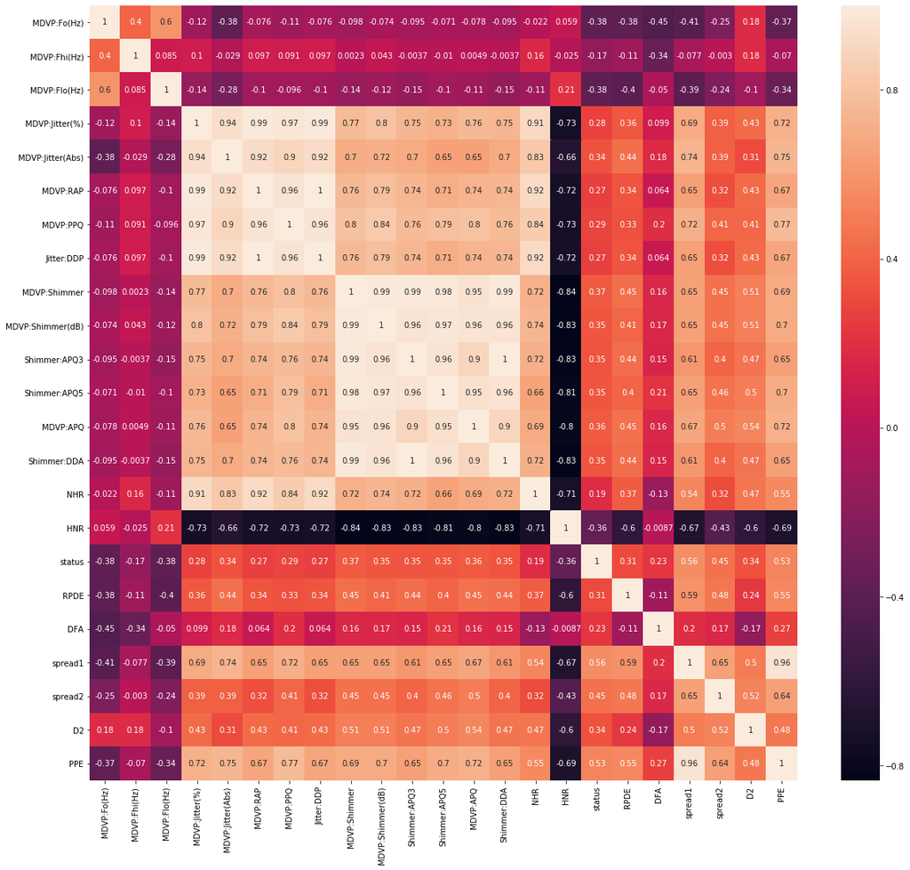

```python
plt.figure(figsize=(20, 18))
sns.heatmap(df.corr(), annot=True)
```

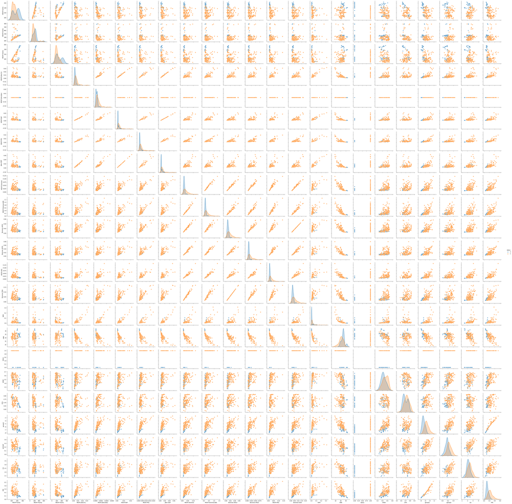

```python
sns.pairplot(df, hue="status")
```

- Features that are evenly disributed.
  - Spread1
  - Spread2
  - D2
  - HNR
  - DFA
- Rest of the features are right skewed.

```python
from IPython.display import display
pd.options.display.max_columns = None
```

```python
# Create correlation matrix
corr_matrix = df.corr().abs()

# Select upper triangle of correlation matrix
upper = corr_matrix.where(np.triu(np.ones(corr_matrix.shape), k=1).astype(np.bool))

# retianing only the columns that has more than 0.95 corelation
to_drop = [column for column in upper.columns if any(upper[column] > 0.90)]

# making a deep copy of the ouriginal data frame
df1 = df.copy(deep=True)

# dropping any column that has less than 0.95 corelation score
df1.drop(to_drop, axis=1, inplace=True)
```

### Creating train test split

```python
X = df1.drop(['status', 'name'], axis=1)
y = df1['status']

X_train, X_test, y_train, y_test = train_test_split(X, y, test_size=0.3, random_state=1)
```

### Model Creation

```python
from sklearn.tree import DecisionTreeClassifier
from sklearn.neighbors import KNeighborsClassifier
from sklearn.svm import SVC
import xgboost
from sklearn.ensemble import RandomForestClassifier,AdaBoostClassifier,ExtraTreesClassifier,BaggingClassifier,VotingClassifier
from sklearn import model_selection

#creating model list
models = []
modelscore = []

# Training classifiers
clf1 = DecisionTreeClassifier(max_depth=8,max_features=7,min_samples_split=4)
data = ('DecisionTreeClassifier', clf1)
models.append(data)
clf1 = clf1.fit(X_train, y_train)
score =  clf1.score(X_train, y_train)
modelscore.append(('DecisionTreeClassifier',score))

clf2 = KNeighborsClassifier(n_neighbors=3,)
data = ('KNeighborsClassifier', clf2)
models.append(data)
clf2 = clf2.fit(X_train, y_train)
score =  clf2.score(X_train, y_train)
modelscore.append(('KNeighborsClassifier',score))

clf3 = xgboost.XGBClassifier(learning_rate= 0.01, n_estimators=100, max_depth= 3, subsample= 0.8, colsample_bytree= 1,gamma= 1)
data = ('XGBClassifier', clf3)
models.append(data)
clf3 = clf3.fit(X_train, y_train)
score =  clf3.score(X_train, y_train)
modelscore.append(('XGBClassifier',score))

clf4 = RandomForestClassifier(n_estimators=40,random_state=100)
data = ('RandomForestClassifier', clf4)
models.append(data)
clf4 = clf4.fit(X_train, y_train)
score =  clf4.score(X_train, y_train)
modelscore.append(('RandomForestClassifier',score))

clf5 = AdaBoostClassifier(n_estimators=300, random_state=0)
data = ('AdaBoostClassifier', clf5)
models.append(data)
clf5 = clf5.fit(X_train, y_train)
score =  clf5.score(X_train, y_train)
modelscore.append(('AdaBoostClassifier',score))

clf6 = ExtraTreesClassifier(n_estimators=100, max_depth=None, random_state=0)
data = ('ExtraTreesClassifier', clf6)
models.append(data)
clf6 = clf6.fit(X_train, y_train)
score =  clf6.score(X_train, y_train)
modelscore.append(('ExtraTreesClassifier',score))

clf7 = SVC(gamma='scale',probability=True)
data = ('SVC', clf7)
models.append(data)
clf7 = clf7.fit(X_train, y_train)
score =  clf7.score(X_train, y_train)
modelscore.append(('SVC', score))

clf8 = GradientBoostingClassifier(n_estimators=95)
data = ('GradientBoostingClassifier', clf8)
models.append(data)
clf8 = clf8.fit(X_train, y_train)
score =  clf8.score(X_train, y_train)
modelscore.append(('GradientBoostingClassifier',score))

clf9 = BaggingClassifier(base_estimator = AdaBoostClassifier(),n_estimators = 200)
data = ('BaggingClassifier', clf9)
models.append(data)
clf9 = clf9.fit(X_train, y_train)
score =  clf9.score(X_train, y_train)
modelscore.append(('BaggingClassifier',score))

eclf = VotingClassifier(estimators=[('dt', clf1), ('knn', clf2), ('xgb', clf3), ('rdf',clf4),
                                    ('adb', clf5), ('etc', clf6), ('svc', clf7), ('GBD',clf8), ('BGC', clf9)], voting='soft')
data = ('VotingClassifier', eclf)
models.append(data)
eclf = eclf.fit(X_train, y_train)
score =  eclf.score(X_train, y_train)
modelscore.append(('VotingClassifier',score))
```

#### Visualize Model Performance on Training Data

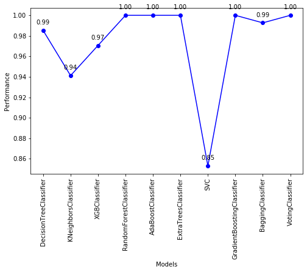

```python
plt.clf()
plt.rcParams['figure.figsize'] = (8, 5)

model, score  = zip(*modelscore)

# 'bo-' means blue color, round points, solid lines
plt.plot(model,score,'bo-')

# zip joins x and y coordinates in pairs
for x,y in zip(model,score):

    label = "{:.2f}".format(y)

    plt.annotate(label, # this is the text
                 (x,y), # this is the point to label
                 textcoords="offset points", # how to position the text
                 xytext=(0,10), # distance from text to points (x,y)
                 ha='center') # horizontal alignment can be left, right or center

plt.xlabel("Models")
plt.xticks(rotation='vertical')
plt.ylabel("Performance")
plt.show()
```

### Training and Evaluation

```python
accscore = []
for model in models:
    y_pred = model[1].predict(X_test)
    acc = accuracy_score(y_test, y_pred)
    accscore.append((acc, model[0]))
```

#### Visualize Model Performance on Test Data

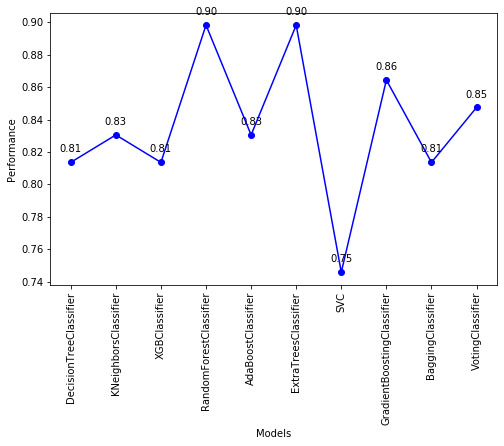

```python
plt.clf()
plt.rcParams['figure.figsize'] = (8, 5)

score, model = zip(*accscore)

# 'bo-' means blue color, round points, solid lines
plt.plot(model,score,'bo-')

# zip joins x and y coordinates in pairs
for x,y in zip(model,score):

    label = "{:.2f}".format(y)

    plt.annotate(label, # this is the text
                 (x,y), # this is the point to label
                 textcoords="offset points", # how to position the text
                 xytext=(0,10), # distance from text to points (x,y)
                 ha='center') # horizontal alignment can be left, right or center

plt.xlabel("Models")
plt.xticks(rotation='vertical')
plt.ylabel("Performance")
plt.show()
```

### Findings on the Initial Iteration:

- RandomForestClassifier and ExtraTreeClassifier are providing a accuracy of 90%, however in problems that are related to the medical illness prediction accuracy of this rate is not sufficient.
- We have droped cetrain columns based on correlation and have dropped name column in the above iteration, we will try to retain the name column in the next iteration and do a GridSearch for finding best parameters.

## Next Iteration

```python
df = pd.read_csv('parkinsons.data')
df.head()
```

|  | name | MDVP:Fo(Hz) | MDVP:Fhi(Hz) | MDVP:Flo(Hz) | MDVP:Jitter(%) | MDVP:Jitter(Abs) | MDVP:RAP | MDVP:PPQ | Jitter:DDP | MDVP:Shimmer | MDVP:Shimmer(dB) | Shimmer:APQ3 | Shimmer:APQ5 | MDVP:APQ | Shimmer:DDA | NHR | HNR | status | RPDE | DFA | spread1 | spread2 | D2 | PPE |
| --- | --- | --- | --- | --- | --- | --- | --- | --- | --- | --- | --- | --- | --- | --- | --- | --- | --- | --- | --- | --- | --- | --- | --- | --- |
| 0 | phon_R01_S01_1 | 119.992 | 157.302 | 74.997 | 0.00784 | 0.00007 | 0.00370 | 0.00554 | 0.01109 | 0.04374 | 0.426 | 0.02182 | 0.03130 | 0.02971 | 0.06545 | 0.02211 | 21.033 | 1 | 0.414783 | 0.815285 | -4.813031 | 0.266482 | 2.301442 | 0.284654 |
| 1 | phon_R01_S01_2 | 122.400 | 148.650 | 113.819 | 0.00968 | 0.00008 | 0.00465 | 0.00696 | 0.01394 | 0.06134 | 0.626 | 0.03134 | 0.04518 | 0.04368 | 0.09403 | 0.01929 | 19.085 | 1 | 0.458359 | 0.819521 | -4.075192 | 0.335590 | 2.486855 | 0.368674 |
| 2 | phon_R01_S01_3 | 116.682 | 131.111 | 111.555 | 0.01050 | 0.00009 | 0.00544 | 0.00781 | 0.01633 | 0.05233 | 0.482 | 0.02757 | 0.03858 | 0.03590 | 0.08270 | 0.01309 | 20.651 | 1 | 0.429895 | 0.825288 | -4.443179 | 0.311173 | 2.342259 | 0.332634 |
| 3 | phon_R01_S01_4 | 116.676 | 137.871 | 111.366 | 0.00997 | 0.00009 | 0.00502 | 0.00698 | 0.01505 | 0.05492 | 0.517 | 0.02924 | 0.04005 | 0.03772 | 0.08771 | 0.01353 | 20.644 | 1 | 0.434969 | 0.819235 | -4.117501 | 0.334147 | 2.405554 | 0.368975 |
| 4 | phon_R01_S01_5 | 116.014 | 141.781 | 110.655 | 0.01284 | 0.00011 | 0.00655 | 0.00908 | 0.01966 | 0.06425 | 0.584 | 0.03490 | 0.04825 | 0.04465 | 0.10470 | 0.01767 | 19.649 | 1 | 0.417356 | 0.823484 | -3.747787 | 0.234513 | 2.332180 | 0.410335 |

### Exploratory Data Analysis

```python
df.info()
```

```
<class 'pandas.core.frame.DataFrame'>
RangeIndex: 195 entries, 0 to 194
Data columns (total 24 columns):
name                195 non-null object
MDVP:Fo(Hz)         195 non-null float64
MDVP:Fhi(Hz)        195 non-null float64
MDVP:Flo(Hz)        195 non-null float64
MDVP:Jitter(%)      195 non-null float64
MDVP:Jitter(Abs)    195 non-null float64
MDVP:RAP            195 non-null float64
MDVP:PPQ            195 non-null float64
Jitter:DDP          195 non-null float64
MDVP:Shimmer        195 non-null float64
MDVP:Shimmer(dB)    195 non-null float64
Shimmer:APQ3        195 non-null float64
Shimmer:APQ5        195 non-null float64
MDVP:APQ            195 non-null float64
Shimmer:DDA         195 non-null float64
NHR                 195 non-null float64
HNR                 195 non-null float64
status              195 non-null int64
RPDE                195 non-null float64
DFA                 195 non-null float64
spread1             195 non-null float64
spread2             195 non-null float64
D2                  195 non-null float64
PPE                 195 non-null float64
dtypes: float64(22), int64(1), object(1)
memory usage: 36.6+ KB
```

```python
df.describe().T
```

|  | count | mean | std | min | 25% | 50% | 75% | max |
| --- | --- | --- | --- | --- | --- | --- | --- | --- |
| MDVP:Fo(Hz) | 195.0 | 154.228641 | 41.390065 | 88.333000 | 117.572000 | 148.790000 | 182.769000 | 260.105000 |
| MDVP:Fhi(Hz) | 195.0 | 197.104918 | 91.491548 | 102.145000 | 134.862500 | 175.829000 | 224.205500 | 592.030000 |
| MDVP:Flo(Hz) | 195.0 | 116.324631 | 43.521413 | 65.476000 | 84.291000 | 104.315000 | 140.018500 | 239.170000 |
| MDVP:Jitter(%) | 195.0 | 0.006220 | 0.004848 | 0.001680 | 0.003460 | 0.004940 | 0.007365 | 0.033160 |
| MDVP:Jitter(Abs) | 195.0 | 0.000044 | 0.000035 | 0.000007 | 0.000020 | 0.000030 | 0.000060 | 0.000260 |
| MDVP:RAP | 195.0 | 0.003306 | 0.002968 | 0.000680 | 0.001660 | 0.002500 | 0.003835 | 0.021440 |
| MDVP:PPQ | 195.0 | 0.003446 | 0.002759 | 0.000920 | 0.001860 | 0.002690 | 0.003955 | 0.019580 |
| Jitter:DDP | 195.0 | 0.009920 | 0.008903 | 0.002040 | 0.004985 | 0.007490 | 0.011505 | 0.064330 |
| MDVP:Shimmer | 195.0 | 0.029709 | 0.018857 | 0.009540 | 0.016505 | 0.022970 | 0.037885 | 0.119080 |
| MDVP:Shimmer(dB) | 195.0 | 0.282251 | 0.194877 | 0.085000 | 0.148500 | 0.221000 | 0.350000 | 1.302000 |
| Shimmer:APQ3 | 195.0 | 0.015664 | 0.010153 | 0.004550 | 0.008245 | 0.012790 | 0.020265 | 0.056470 |
| Shimmer:APQ5 | 195.0 | 0.017878 | 0.012024 | 0.005700 | 0.009580 | 0.013470 | 0.022380 | 0.079400 |
| MDVP:APQ | 195.0 | 0.024081 | 0.016947 | 0.007190 | 0.013080 | 0.018260 | 0.029400 | 0.137780 |
| Shimmer:DDA | 195.0 | 0.046993 | 0.030459 | 0.013640 | 0.024735 | 0.038360 | 0.060795 | 0.169420 |
| NHR | 195.0 | 0.024847 | 0.040418 | 0.000650 | 0.005925 | 0.011660 | 0.025640 | 0.314820 |
| HNR | 195.0 | 21.885974 | 4.425764 | 8.441000 | 19.198000 | 22.085000 | 25.075500 | 33.047000 |
| status | 195.0 | 0.753846 | 0.431878 | 0.000000 | 1.000000 | 1.000000 | 1.000000 | 1.000000 |
| RPDE | 195.0 | 0.498536 | 0.103942 | 0.256570 | 0.421306 | 0.495954 | 0.587562 | 0.685151 |
| DFA | 195.0 | 0.718099 | 0.055336 | 0.574282 | 0.674758 | 0.722254 | 0.761881 | 0.825288 |
| spread1 | 195.0 | -5.684397 | 1.090208 | -7.964984 | -6.450096 | -5.720868 | -5.046192 | -2.434031 |
| spread2 | 195.0 | 0.226510 | 0.083406 | 0.006274 | 0.174351 | 0.218885 | 0.279234 | 0.450493 |
| D2 | 195.0 | 2.381826 | 0.382799 | 1.423287 | 2.099125 | 2.361532 | 2.636456 | 3.671155 |
| PPE | 195.0 | 0.206552 | 0.090119 | 0.044539 | 0.137451 | 0.194052 | 0.252980 | 0.527367 |

```python
# Create correlation matrix
corr_matrix = df.corr().abs()

# Select upper triangle of correlation matrix
upper = corr_matrix.where(np.triu(np.ones(corr_matrix.shape), k=1).astype(np.bool))

# retianing only the columns that has more than 0.95 corelation
to_drop = [column for column in upper.columns if any(upper[column] > 0.95)]

# making a deep copy of the ouriginal data frame
df1 = df.copy(deep=True)

# dropping any column that has less than 0.95 corelation score
df1.drop(to_drop, axis=1, inplace=True)
```

```python
# Label Encoding the non numerical columns
from sklearn.preprocessing import LabelEncoder

# doing label encoing to make 'name' column usable in models
le = LabelEncoder()
df1['name'] = le.fit_transform(df['name'])
df1['name'] = df1['name'].astype('int')
```

```python
X = df1.drop(['status'], axis=1)
y = df1['status']

X_train, X_test, y_train, y_test = train_test_split(X, y, test_size=0.3, random_state=1)
```

## Model Creation

```python
#creating model list
models = []
modelscore = []

# Training classifiers
clf1 = DecisionTreeClassifier(max_depth=8,max_features=7,min_samples_split=4)
data = ('DecisionTreeClassifier', clf1)
models.append(data)
clf1 = clf1.fit(X_train, y_train)
score =  clf1.score(X_train, y_train)
modelscore.append(('DecisionTreeClassifier',score))

clf2 = KNeighborsClassifier(n_neighbors=3,)
data = ('KNeighborsClassifier', clf2)
models.append(data)
clf2 = clf2.fit(X_train, y_train)
score =  clf2.score(X_train, y_train)
modelscore.append(('KNeighborsClassifier',score))

clf3 = xgboost.XGBClassifier(learning_rate= 0.01, n_estimators=100, max_depth= 3, subsample= 0.8, colsample_bytree= 1,gamma= 1)
data = ('XGBClassifier', clf3)
models.append(data)
clf3 = clf3.fit(X_train, y_train)
score =  clf3.score(X_train, y_train)
modelscore.append(('XGBClassifier',score))

clf4 = RandomForestClassifier(n_estimators=40,random_state=100)
data = ('RandomForestClassifier', clf4)
models.append(data)
clf4 = clf4.fit(X_train, y_train)
score =  clf4.score(X_train, y_train)
modelscore.append(('RandomForestClassifier',score))

clf5 = AdaBoostClassifier(n_estimators=300, random_state=0)
data = ('AdaBoostClassifier', clf5)
models.append(data)
clf5 = clf5.fit(X_train, y_train)
score =  clf5.score(X_train, y_train)
modelscore.append(('AdaBoostClassifier',score))

clf6 = ExtraTreesClassifier(n_estimators=100, max_depth=None, random_state=0)
data = ('ExtraTreesClassifier', clf6)
models.append(data)
clf6 = clf6.fit(X_train, y_train)
score =  clf6.score(X_train, y_train)
modelscore.append(('ExtraTreesClassifier',score))

clf7 = SVC(C=10, kernel='rbf', gamma= 0.001, probability=True)
data = ('SVC', clf7)
models.append(data)
clf7 = clf7.fit(X_train, y_train)
score =  clf7.score(X_train, y_train)
modelscore.append(('SVC', score))

clf8 = GradientBoostingClassifier(n_estimators=95)
data = ('GradientBoostingClassifier', clf8)
models.append(data)
clf8 = clf8.fit(X_train, y_train)
score =  clf8.score(X_train, y_train)
modelscore.append(('GradientBoostingClassifier',score))

clf9 = BaggingClassifier(base_estimator = AdaBoostClassifier(),n_estimators = 200)
data = ('BaggingClassifier', clf9)
models.append(data)
clf9 = clf9.fit(X_train, y_train)
score =  clf9.score(X_train, y_train)
modelscore.append(('BaggingClassifier',score))

eclf = VotingClassifier(estimators=[('dt', clf1), ('knn', clf2), ('xgb', clf3), ('rdf',clf4),
                                    ('adb', clf5), ('etc', clf6), ('svc', clf7), ('GBD',clf8), ('BGC', clf9)], voting='soft')
data = ('VotingClassifier', eclf)
models.append(data)
eclf = eclf.fit(X_train, y_train)
score =  eclf.score(X_train, y_train)
modelscore.append(('VotingClassifier',score))
```

### Visualize Model Performance on Training Data

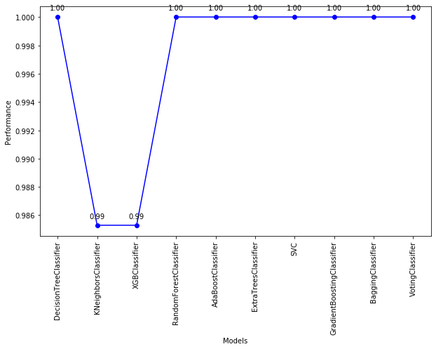

```python
plt.clf()
plt.rcParams['figure.figsize'] = (10, 6)

model, score  = zip(*modelscore)

# 'bo-' means blue color, round points, solid lines
plt.plot(model,score,'bo-')

# zip joins x and y coordinates in pairs
for x,y in zip(model,score):

    label = "{:.2f}".format(y)

    plt.annotate(label, # this is the text
                 (x,y), # this is the point to label
                 textcoords="offset points", # how to position the text
                 xytext=(0,10), # distance from text to points (x,y)
                 ha='center') # horizontal alignment can be left, right or center

plt.xlabel("Models")
plt.xticks(rotation='vertical')
plt.ylabel("Performance")
plt.show()
```

### Training and Evaluation

```python
accscore = []
for model in models:
    y_pred = model[1].predict(X_test)
    acc = accuracy_score(y_test, y_pred)
    accscore.append((acc, model[0]))
```

### Visualize Model Performance on Test Data

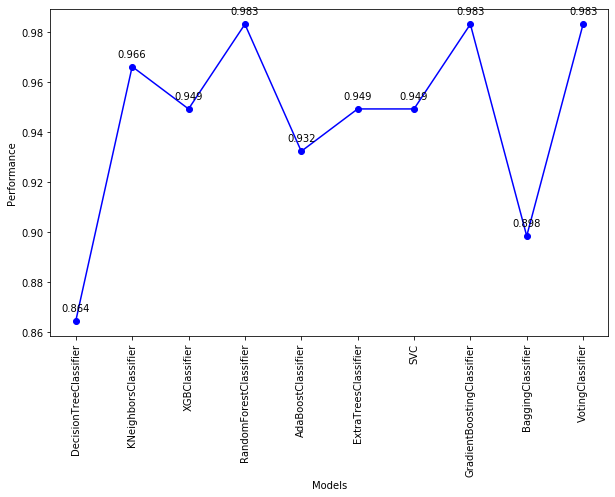

```python
plt.clf()
plt.rcParams['figure.figsize'] = (10,6)

score, model = zip(*accscore)

# 'bo-' means blue color, round points, solid lines
plt.plot(model,score,'bo-')

# zip joins x and y coordinates in pairs
for x,y in zip(model,score):

    label = "{:.3f}".format(y)

    plt.annotate(label, # this is the text
                 (x,y), # this is the point to label
                 textcoords="offset points", # how to position the text
                 xytext=(0,10), # distance from text to points (x,y)
                 ha='center') # horizontal alignment can be left, right or center

plt.xlabel("Models")
plt.xticks(rotation='vertical')
plt.ylabel("Performance")
plt.show()
```

- We see that the model using RandomForestClassifier, GradientBoostingClassifier and Voting Classified are giving a accuracy of 98.3% .

### Using GridSearchCV for fine tuning the model

```python
# for Grid Search model
from sklearn.model_selection import GridSearchCV
from sklearn.metrics import classification_report

# Set the parameters by cross-validation
tuned_parameters = [{'kernel': ['rbf'], 'gamma': [1e-3, 1e-4],
                     'C': [1, 10, 100, 1000]},
                    {'kernel': ['linear'], 'C': [1, 10, 100, 1000]}]

scores = ['precision', 'recall']

for score in scores:
    print("# Tuning hyper-parameters for %s" % score)
    print()

    clf = GridSearchCV(
        SVC(), tuned_parameters, scoring='%s_macro' % score
    )
    clf.fit(X_train, y_train)

    print("Best parameters set found on development set:")
    print()
    print(clf.best_params_)
    print()
    print("Grid scores on development set:")
    print()
    means = clf.cv_results_['mean_test_score']
    stds = clf.cv_results_['std_test_score']
    for mean, std, params in zip(means, stds, clf.cv_results_['params']):
        print("%0.3f (+/-%0.03f) for %r"
              % (mean, std * 2, params))
    print()

    print("Detailed classification report:")
    print()
    print("The model is trained on the full development set.")
    print("The scores are computed on the full evaluation set.")
    print()
    y_true, y_pred = y_test, clf.predict(X_test)
    print(classification_report(y_true, y_pred))
    print()

# Note the problem is too easy: the hyperparameter plateau is too flat and the
# output model is the same for precision and recall with ties in quality.
```

```
# Tuning hyper-parameters for precision
```

```
Best parameters set found on development set:

{'C': 10, 'gamma': 0.001, 'kernel': 'rbf'}

Grid scores on development set:

0.961 (+/-0.020) for {'C': 1, 'gamma': 0.001, 'kernel': 'rbf'}
0.932 (+/-0.028) for {'C': 1, 'gamma': 0.0001, 'kernel': 'rbf'}
0.982 (+/-0.012) for {'C': 10, 'gamma': 0.001, 'kernel': 'rbf'}
0.933 (+/-0.070) for {'C': 10, 'gamma': 0.0001, 'kernel': 'rbf'}
0.982 (+/-0.012) for {'C': 100, 'gamma': 0.001, 'kernel': 'rbf'}
0.958 (+/-0.061) for {'C': 100, 'gamma': 0.0001, 'kernel': 'rbf'}
0.982 (+/-0.012) for {'C': 1000, 'gamma': 0.001, 'kernel': 'rbf'}
0.938 (+/-0.117) for {'C': 1000, 'gamma': 0.0001, 'kernel': 'rbf'}
0.843 (+/-0.155) for {'C': 1, 'kernel': 'linear'}
0.839 (+/-0.138) for {'C': 10, 'kernel': 'linear'}
0.760 (+/-0.190) for {'C': 100, 'kernel': 'linear'}
0.828 (+/-0.181) for {'C': 1000, 'kernel': 'linear'}

Detailed classification report:

The model is trained on the full development set.
The scores are computed on the full evaluation set.

              precision    recall  f1-score   support

           0       1.00      0.84      0.91        19
           1       0.93      1.00      0.96        40

    accuracy                           0.95        59
   macro avg       0.97      0.92      0.94        59
weighted avg       0.95      0.95      0.95        59


# Tuning hyper-parameters for recall

Best parameters set found on development set:

{'C': 100, 'gamma': 0.0001, 'kernel': 'rbf'}

```

[output cut: 13 more lines]

```
0.771 (+/-0.125) for {'C': 1000, 'kernel': 'linear'}

Detailed classification report:

The model is trained on the full development set.
The scores are computed on the full evaluation set.

              precision    recall  f1-score   support

           0       0.89      0.89      0.89        19
           1       0.95      0.95      0.95        40

    accuracy                           0.93        59
   macro avg       0.92      0.92      0.92        59
weighted avg       0.93      0.93      0.93        59
```

### Using GridSearchCV On Model:

```python
grid_param = {
    'n_estimators': [100, 300, 500, 800, 1000],
    'criterion': ['friedman_mse']
}
```

```python
model = GridSearchCV(estimator=clf8,       #GradientBoostingClassifier
                     param_grid=grid_param,
                     scoring='accuracy',
                     cv=5,
                     n_jobs=-1)
```

```python
gscv_result = model.fit(X_train, y_train)
```

```python
y_pred = model.predict(X_test)
acc = accuracy_score(y_test, y_pred)
print(acc)
```

```
0.9830508474576272
```

```python
the_best_params = gscv_result.best_params_
print(the_best_params)
```

```
{'criterion': 'friedman_mse', 'n_estimators': 800}
```

We have used the best params given by GridSearch in GradientBoostingClassifier model and we got good accuracy. After made changes (included 'name' column) on the columns, we have got the good accuracy

- **GradientBoostingClassifier** gives accuracy of **98.3%** which is a good model when we are predicting a medical related issues.